# SYNC_Patient_data

GARBA Moussa

2/4/2021

# Synthetic Data Generation via Gaussian Copula : SYNC healthcare data - Project

- Problem: 1. Assuming we are given only these summary values, how do we reconstruct/trace back the data for each patient, on each one of the variables “trt” “age” “bmi” “gender” “response”, particularly if we are additionally informed that some patients have missing values in one or more of those variables?.
- Problem 2. How do we measure the accuracy between the reconstructed data and the original data?. In this case, we have access to the original individual data, so if we have the methodology to measure the difference between the reconstructed and the original data, we can do so and then try it with other simulated data to see how robust our approach is.
- The central idea of SYNC is to fit Gaussian copula models to each of the low- resolution datasets in order to correctly capture dependencies and marginal distributions, and then sample from the fitted models to obtain the desired high-resolution subsets.
- Synthetic data is a data object that is artificially created rather than collected from actual events. It is widely used in applications like harmonizing multiple data sources or augmenting existing data.
- Downscaling : efficiently produce high quality data, generate high-resolution data (e.g., individual level records) from multiple low-resolution sources (e.g., averages of many individual records).
- Practitioners often find individual level data far more appealing, as aggregated data lack information such as variances and distributions of variables.
- Downscaled synthetic data to be useful : it needs to be *fair* and *consistent*.
- Fair : simulated data should mimic realistic distributions and correlations of the true population as closely as possible.
- Consistent : downscaled samples, the results need to be consistent with the original data.

SYNC (Synthetic Data Generation via Gaussian Copula) to simulate microdata by sampling features in batches. The concept is motivated by [Copula-based approach to synthetic population generation] and [Dependence- preserving approach to synthesizing household characteristics].

The rationale behind SYNC is that features can be segmented into dis- tinct batches based on their correlations, which reduces the high dimensional problem into several sub-problems in lower dimensions.

Feature dependency in high dimensions is hard to evaluate via common methods due to its complexity and computation requirements, and as such, Gaussian copula, a family of multivariate distributions that is capable of capturing dependencies among random variables, becomes an ideal candidate for the application.

```r
# read in the libraries we're going to use
library(tidyverse) # general utility & workflow functions
library(tidytext) # tidy implimentation of NLP methods
library(topicmodels) # for LDA topic modelling
library(tm) # general text mining functions, making document term matrixes
library(SnowballC) # for stemming
library(readxl) # for read xlsx file
library(scales)
```

```r
library(plotly)
data <- read.csv("/Users/garbamoussa/Desktop/Bureau/R/Patient_data_SYNC/Data/individual_data.csv",  sep=",", header = TRUE)
View(data)
```

```r
data
```

```
##         X     trial            trt age  bmi  male response
## 1       1 UNCOVER-2     Etanercept  51 34.5  TRUE        0
## 2       2 UNCOVER-2     Etanercept  64 24.2  TRUE        1
## 3       3 UNCOVER-2     Etanercept  59 26.1  TRUE        1
## 4       4 UNCOVER-2     Etanercept  54 19.7  TRUE        0
## 5       5 UNCOVER-2     Etanercept  50 30.3  TRUE        0
## 6       6 UNCOVER-2     Etanercept  57 25.8  TRUE        1
## 7       7 UNCOVER-2     Etanercept  36 30.3  TRUE        0
## 8       8 UNCOVER-2     Etanercept  54 38.1 FALSE        1
## 9       9 UNCOVER-2     Etanercept  50 30.3 FALSE        0
## 10     10 UNCOVER-2     Etanercept  26 27.2  TRUE        1
## 11     11 UNCOVER-2     Etanercept  61 31.5  TRUE        0
## 12     12 UNCOVER-2     Etanercept  29 23.4 FALSE        0
## 13     13 UNCOVER-2     Etanercept  52 27.5 FALSE        1
## 14     14 UNCOVER-2     Etanercept  42 22.7 FALSE        1
```

[output cut: 1207 more lines]

```r
data %>% map_dbl(n_distinct)
```

```
##        X    trial      trt      age      bmi     male response
##     1221        1        4       64      248        2        2
```

```r
data %>% map_df(~(data.frame(n_distinct = n_distinct(.x),
                                  class = class(.x))))
```

```
##   n_distinct     class
## 1       1221   integer
## 2          1 character
## 3          4 character
## 4         64   integer
## 5        248   numeric
## 6          2   logical
## 7          2   integer
```

```r
slice(data,10:15)
```

```
##    X     trial        trt age  bmi  male response
## 1 10 UNCOVER-2 Etanercept  26 27.2  TRUE        1
## 2 11 UNCOVER-2 Etanercept  61 31.5  TRUE        0
## 3 12 UNCOVER-2 Etanercept  29 23.4 FALSE        0
## 4 13 UNCOVER-2 Etanercept  52 27.5 FALSE        1
## 5 14 UNCOVER-2 Etanercept  42 22.7 FALSE        1
## 6 15 UNCOVER-2 Etanercept  58 34.6  TRUE        0
```

```r
top_n(data, 2, bmi)
```

[output not shown]

```r
summarise_each(data, funs(mean))
```

```
##     X trial trt      age bmi      male  response
## 1 611    NA  NA 46.09173  NA 0.6764947 0.6011466
```

```r
group_by(data,trt)
```

```
## # A tibble: 1,221 x 7
## # Groups:   trt [4]
##        X trial     trt          age   bmi male  response
##    <int> <chr>     <chr>      <int> <dbl> <lgl>    <int>
##  1     1 UNCOVER-2 Etanercept    51  34.5 TRUE         0
##  2     2 UNCOVER-2 Etanercept    64  24.2 TRUE         1
##  3     3 UNCOVER-2 Etanercept    59  26.1 TRUE         1
##  4     4 UNCOVER-2 Etanercept    54  19.7 TRUE         0
##  5     5 UNCOVER-2 Etanercept    50  30.3 TRUE         0
##  6     6 UNCOVER-2 Etanercept    57  25.8 TRUE         1
##  7     7 UNCOVER-2 Etanercept    36  30.3 TRUE         0
##  8     8 UNCOVER-2 Etanercept    54  38.1 FALSE        1
##  9     9 UNCOVER-2 Etanercept    50  30.3 FALSE        0
## 10    10 UNCOVER-2 Etanercept    26  27.2 TRUE         1
## # … with 1,211 more rows
```

```r
data %>% map_df(~(data.frame(n_distinct = n_distinct(.x),
                                  class = class(.x))),
                     .id = "variable")
```

```
##   variable n_distinct     class
## 1        X       1221   integer
## 2    trial          1 character
## 3      trt          4 character
## 4      age         64   integer
## 5      bmi        248   numeric
## 6     male          2   logical
## 7 response          2   integer
```

```r
male_trt <- data %>% distinct(male, trt)
male_trt
```

[output not shown]

```r
glimpse(data)
```

```
## Rows: 1,221
## Columns: 7
## $ X        <int> 1, 2, 3, 4, 5, 6, 7, 8, 9, 10, 11, 12, 13, 14, 15, 16, 17, 1…
## $ trial    <chr> "UNCOVER-2", "UNCOVER-2", "UNCOVER-2", "UNCOVER-2", "UNCOVER…
## $ trt      <chr> "Etanercept", "Etanercept", "Etanercept", "Etanercept", "Eta…
## $ age      <int> 51, 64, 59, 54, 50, 57, 36, 54, 50, 26, 61, 29, 52, 42, 58, …
## $ bmi      <dbl> 34.5, 24.2, 26.1, 19.7, 30.3, 25.8, 30.3, 38.1, 30.3, 27.2, …
## $ male     <lgl> TRUE, TRUE, TRUE, TRUE, TRUE, TRUE, TRUE, FALSE, FALSE, TRUE…
## $ response <int> 0, 1, 1, 0, 0, 1, 0, 1, 0, 1, 0, 0, 1, 1, 0, 1, 0, 0, 0, 1, …
```

```r
sapply(data, class)
```

```
##           X       trial         trt         age         bmi        male
##   "integer" "character" "character"   "integer"   "numeric"   "logical"
##    response
##   "integer"
```

```r
data %>%
group_by(trial) %>%
summarise(avg = mean(age) ) %>%
arrange(avg)
```

```
## # A tibble: 1 x 2
##   trial       avg
##   <chr>     <dbl>
## 1 UNCOVER-2  46.1
```

```r
data %>%
group_by(trt) %>%
summarise(avg = mean(age) ) %>%
arrange(avg)
```

```
## # A tibble: 4 x 2
##   trt              avg
##   <chr>          <dbl>
## 1 Placebo         45.2
## 2 Ixekizumab Q2W  45.5
## 3 Ixekizumab Q4W  45.6
## 4 Etanercept      47.5
```

```r
arrange(data, age)
```

```
##         X     trial            trt age  bmi  male response
## 1     374 UNCOVER-2 Ixekizumab Q2W  18 25.3  TRUE        0
## 2     379 UNCOVER-2 Ixekizumab Q2W  18 26.1  TRUE        1
## 3     487 UNCOVER-2 Ixekizumab Q2W  18 22.1  TRUE        1
## 4     569 UNCOVER-2 Ixekizumab Q2W  18 21.2 FALSE        0
## 5     659 UNCOVER-2 Ixekizumab Q2W  18 26.1  TRUE        1
## 6     857 UNCOVER-2 Ixekizumab Q4W  18 22.8 FALSE        0
## 7      61 UNCOVER-2     Etanercept  19 41.4  TRUE        0
## 8     325 UNCOVER-2     Etanercept  19 29.3  TRUE        1
## 9     413 UNCOVER-2 Ixekizumab Q2W  19 21.2 FALSE        1
## 10    696 UNCOVER-2 Ixekizumab Q2W  19 25.3  TRUE        1
## 11   1006 UNCOVER-2 Ixekizumab Q4W  19 32.0  TRUE        1
## 12    287 UNCOVER-2     Etanercept  20 27.5 FALSE        1
## 13    377 UNCOVER-2 Ixekizumab Q2W  20 25.3 FALSE        1
## 14    476 UNCOVER-2 Ixekizumab Q2W  20 21.1 FALSE        1
```

[output cut: 1207 more lines]

```r
filter(data,age> 70 & bmi < 30)
```

```
##       X     trial            trt age  bmi  male response
## 1    47 UNCOVER-2     Etanercept  78 24.2  TRUE        0
## 2   187 UNCOVER-2     Etanercept  71 28.7 FALSE        1
## 3   366 UNCOVER-2 Ixekizumab Q2W  77 23.3 FALSE        1
## 4   414 UNCOVER-2 Ixekizumab Q2W  77 28.4  TRUE        1
## 5   418 UNCOVER-2 Ixekizumab Q2W  84 26.8  TRUE        1
## 6   430 UNCOVER-2 Ixekizumab Q2W  84 27.7 FALSE        1
## 7   484 UNCOVER-2 Ixekizumab Q2W  75 27.9 FALSE        1
## 8   586 UNCOVER-2 Ixekizumab Q2W  73 23.3 FALSE        1
## 9   641 UNCOVER-2 Ixekizumab Q2W  72 27.9 FALSE        1
## 10  748 UNCOVER-2 Ixekizumab Q4W  80 23.9  TRUE        1
## 11  822 UNCOVER-2 Ixekizumab Q4W  72 28.4  TRUE        0
## 12 1134 UNCOVER-2        Placebo  76 27.8  TRUE        0
```

```r
distinct(data)
```

```
##         X     trial            trt age  bmi  male response
## 1       1 UNCOVER-2     Etanercept  51 34.5  TRUE        0
## 2       2 UNCOVER-2     Etanercept  64 24.2  TRUE        1
## 3       3 UNCOVER-2     Etanercept  59 26.1  TRUE        1
## 4       4 UNCOVER-2     Etanercept  54 19.7  TRUE        0
## 5       5 UNCOVER-2     Etanercept  50 30.3  TRUE        0
## 6       6 UNCOVER-2     Etanercept  57 25.8  TRUE        1
## 7       7 UNCOVER-2     Etanercept  36 30.3  TRUE        0
## 8       8 UNCOVER-2     Etanercept  54 38.1 FALSE        1
## 9       9 UNCOVER-2     Etanercept  50 30.3 FALSE        0
## 10     10 UNCOVER-2     Etanercept  26 27.2  TRUE        1
## 11     11 UNCOVER-2     Etanercept  61 31.5  TRUE        0
## 12     12 UNCOVER-2     Etanercept  29 23.4 FALSE        0
## 13     13 UNCOVER-2     Etanercept  52 27.5 FALSE        1
## 14     14 UNCOVER-2     Etanercept  42 22.7 FALSE        1
```

[output cut: 1207 more lines]

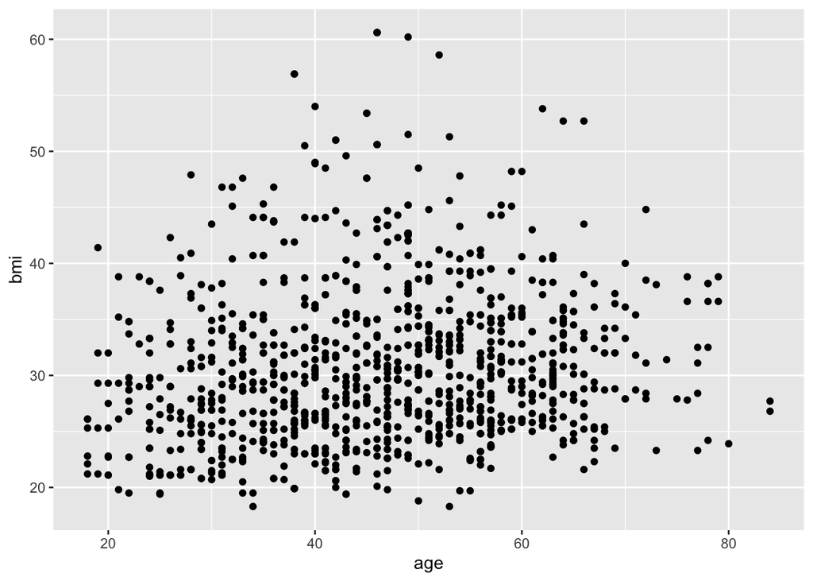

```r
ggplot(data, aes(x=age, y=bmi)) + geom_point()
```

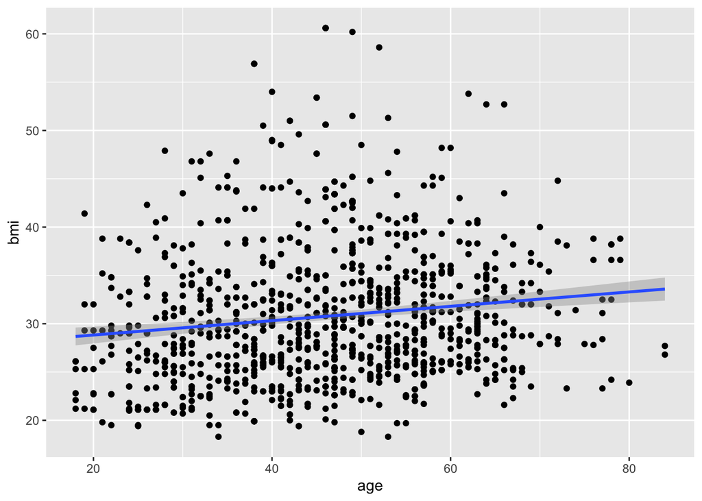

```r
g <-ggplot(data, aes(x=age, y=bmi)) + geom_point() + geom_smooth(method="lm")

plot(g)
```

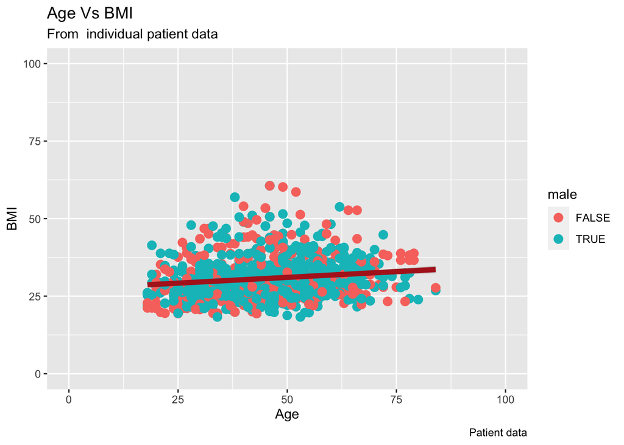

```r
gg <- ggplot(data, aes(x=age, y=bmi)) +
  geom_point(aes(col=male), size=3) +  # Set color to vary based on state categories.
  geom_smooth(method="lm", col="firebrick", size=2) +
  coord_cartesian(xlim=c(0, 100), ylim=c(0, 100)) +
  labs(title="Age Vs BMI", subtitle="From  individual patient data", y="BMI", x="Age", caption="Patient data")
plot(gg)
```